# Ken Griffey, Jr. Career Trajectory

Martin Frigaard

# Motivation

This repo contains an example career trajectory calculation for Ken Griffey, Jr. I’ve borrowed heavily from [Analyzing Baseball Data with R, 2nd Edition](https://www.amazon.com/Analyzing-Baseball-Data-Second-Chapman/dp/0815353510) and [Frontiers in Major League Baseball](https://www.springer.com/gp/book/9781441908308).

## Packages

The two primary packages we will use are `tidyverse` and `Lahman`

```r
library(tidyverse)
library(Lahman)
library(broom)
```

## Get player statistics

```r
kgjr_id <- Lahman::People %>%
  filter(nameFirst == "Ken" &
           nameLast == "Griffey" &
           birthYear == 1969) %>%
  pull(playerID)
kgjr_id
```

```
#>  [1] "griffke02"
```

We need to change the value of missing statistics from the `Batting` table with 0s, which we can do below.

`SF` = Sacrifice flies

`HBP` = Hit by pitch

```r
Batting <- Lahman::Batting %>%
  tidyr::replace_na(list(SF = 0, HBP = 0))
```

Now we write a custom function for getting the player stats with a given `playerID`.

```r
get_stats <- function(player.id) {
  Batting %>%
    dplyr::filter(playerID == player.id) %>%
    dplyr::inner_join(People, by = "playerID") %>%
    dplyr::mutate(birthyear = ifelse(birthMonth >= 7, birthYear + 1, birthYear),
      Age = yearID - birthyear,
      SLG = (H - X2B - X3B - HR + 2 * X2B + 3 * X3B + 4 * HR) / AB,
      OBP = (H + BB + HBP) / (AB + BB + HBP + SF),
      OPS = SLG + OBP) %>%
dplyr::select(Age, SLG, OBP, OPS)
}
```

Now we can view Ken Griffey Jr.’s (`KGJr`) stats over his age (in years).

```r
KGriffeyJr <- get_stats(kgjr_id)
KGriffeyJr %>% rmarkdown::paged_table()
```

| Age | SLG | OBP | OPS |
| --- | --- | --- | --- |
| 19 | 0.4197802 | 0.3287129 | 0.7484931 |
| 20 | 0.4807370 | 0.3663664 | 0.8471034 |
| 21 | 0.5273723 | 0.3990461 | 0.9264184 |
| 22 | 0.5345133 | 0.3614263 | 0.8959395 |
| 23 | 0.6168385 | 0.4081042 | 1.0249427 |
| 24 | 0.6743649 | 0.4016227 | 1.0759876 |
| 25 | 0.4807692 | 0.3789809 | 0.8597501 |
| 26 | 0.6275229 | 0.3924647 | 1.0199876 |
| 27 | 0.6463816 | 0.3821023 | 1.0284839 |
| 28 | 0.6113744 | 0.3652778 | 0.9766522 |

[output cut: 13 more lines]

Now we’ll take a look at `KGJr`’s OPS vs. his age.

## Age vs. slugging percentage and on-base percentage

The OPS is the sum of a player’s slugging percentage and on-base percentage. When we plot it against `KGJr`s age, we can see there is an increase until about age 24, then a gradual decline until age 40.

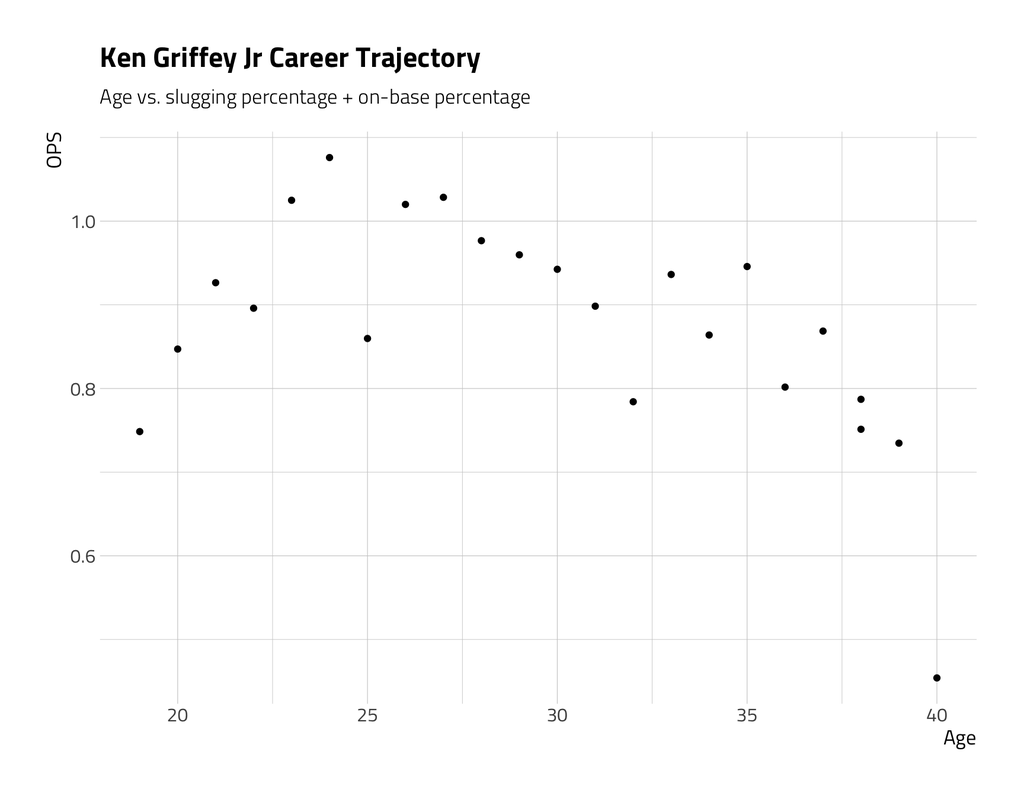

```r
KGriffeyJr %>%
  ggplot2::ggplot(aes(x = Age, y = OPS)) +
  ggplot2::geom_point() +
  hrbrthemes::theme_ipsum_tw(axis_title_size = 13, axis_text_size = 12) +
  ggplot2::labs(title = "Ken Griffey Jr Career Trajectory",
                subtitle = "Age vs. slugging percentage + on-base percentage")
```

## Modeling career performance

We will borrow the model from [Analyzing Baseball Data with R, 2nd Edition](https://www.amazon.com/Analyzing-Baseball-Data-Second-Chapman/dp/0815353510) and fit a quadratic curve to `OPS` and `Age`. > `A + B(Age − 30) + C(Age − 30)^2`

Where `A`, `B`, and `C` are the following,

`A` = the predicted value of OPS when the player is 30 years old

`30 - (B/2C)` = The age where the player is estimated to have his peak batting performance during his career (PEAK AGE).

`A - (B^2/4C)` = maximum value of the curve or the estimated largest `OPS` of the player over his career.

`C` = the degree of curvature in the quadratic function (the larger the number, the steeper the climb and subsequent decline)

Written as a formula for R to interpret, it looks like this:

`OPS ~ I(Age - 30) + I((Age - 30)^2)`

We’re going to run through each component for this model, then put all the steps together into a function so we can apply it to other players.

### Fit model

```r
fit <- lm(OPS ~ I(Age - 30) + I((Age - 30)^2), data = KGriffeyJr)
fit
```

```
#>
#>  Call:
#>  lm(formula = OPS ~ I(Age - 30) + I((Age - 30)^2), data = KGriffeyJr)
#>
#>  Coefficients:
#>      (Intercept)      I(Age - 30)  I((Age - 30)^2)
#>         0.972763        -0.011983        -0.002385
```

### Get coefficients

Now we get the coefficients for `fit`

```r
b <- coef(fit)
b
```

```
#>      (Intercept)     I(Age - 30) I((Age - 30)^2)
#>       0.97276346     -0.01198292     -0.00238516
```

### Max age

Next we need the age_max, or the `30 - (B/2C)`. We can get this by using the 2nd and 3rd element stored in `b` (which are the coefficients for `I(Age - 30)` and `I((Age - 30)^2)`).

Inspect `b[2]`

```r
b[2]
```

```
#>  I(Age - 30)
#>  -0.01198292
```

Inspect `b[3]`

```r
b[3]
```

```
#>  I((Age - 30)^2)
#>      -0.00238516
```

age max = `30 - [I(Age - 30)] / [I((Age - 30)^2)] / 2`

```r
age_max <- 30 - b[2] / b[3] / 2
age_max
```

```
#>  I(Age - 30)
#>     27.48802
```

### Max OPS value

With our `age_max`, now we just need the `max_value` or `A - (B^2/4C)` which is `b[1] - b[2] ^ 2 / b[3] / 4`

Inspect `b[1]`

```r
b[1]
```

```
#>  (Intercept)
#>    0.9727635
```

max value = `[(Intercept)] - [I(Age - 30)]^2 / [I((Age - 30)^2)] / 4`

```r
max_value <- b[1] - b[2] ^ 2 / b[3] / 4
max_value
```

```
#>  (Intercept)
#>    0.9878139
```

Finally we combine them into a list.

```r
list(fit = fit, age_max = age_max, max_value = max_value)
```

```
#>  $fit
#>
#>  Call:
#>  lm(formula = OPS ~ I(Age - 30) + I((Age - 30)^2), data = KGriffeyJr)
#>
#>  Coefficients:
#>      (Intercept)      I(Age - 30)  I((Age - 30)^2)
#>         0.972763        -0.011983        -0.002385
#>
#>
#>  $age_max
#>  I(Age - 30)
#>     27.48802
#>
#>  $max_value
#>  (Intercept)
#>    0.9878139
```

### Build model function

Now we combine this into a function.

```r
fit_model <- function(d) {

  fit <- lm(OPS ~ I(Age - 30) + I((Age - 30)^2), data = d)

  b <- coef(fit)

  age_max <- 30 - b[2] / b[3] / 2

  max_value <- b[1] - b[2] ^ 2 / b[3] / 4

  list(fit = fit, age_max = age_max, max_value = max_value)
}
```

## Fit model for `KGJr`

Now we can test this function and get the coefficients. We will use `broom::tidy()` to convert the output into a tibble.

```r
kgriffeyjr_fit_model <- fit_model(KGriffeyJr)
KGJrCoefs <- broom::tidy(stats::coef(kgriffeyjr_fit_model$fit))
KGJrCoefs
```

| names | x |
| --- | --- |
| (Intercept) | 0.97276346 |
| I(Age - 30) | -0.01198292 |
| I((Age - 30)^2) | -0.00238516 |

The other two elements in our `kgriffeyjr_fit_model` object are the `age_max` and `max_value`

```r
KGJrMaxAgeMaxOPS <- dplyr::bind_rows(broom::tidy(kgriffeyjr_fit_model$age_max),
                                  broom::tidy(kgriffeyjr_fit_model$max_value))
KGJrMaxAgeMaxOPS
```

| names | x |
| --- | --- |
| I(Age - 30) | 27.4880249 |
| (Intercept) | 0.9878139 |

According to this model:

- `KGJr`s peak age is stored in `KGJrMaxAgeMaxOPS` and is 27.4880249
- `KGJr`’s maximum `OPS` for the curve is also stored in `KGJrMaxAgeMaxOPS` and is estimated to be 0.9878139
- The estimated curvature parameter is the `I((Age - 30)^2)` value: -0.0023852, which means `KGJr`s decrease in `OPS` between his peak age (27.4880249) and one year older is -0.0023852

We can plot this below by creating a few labels for the `Peak Age` and `Max OPS`, and adding a theme.

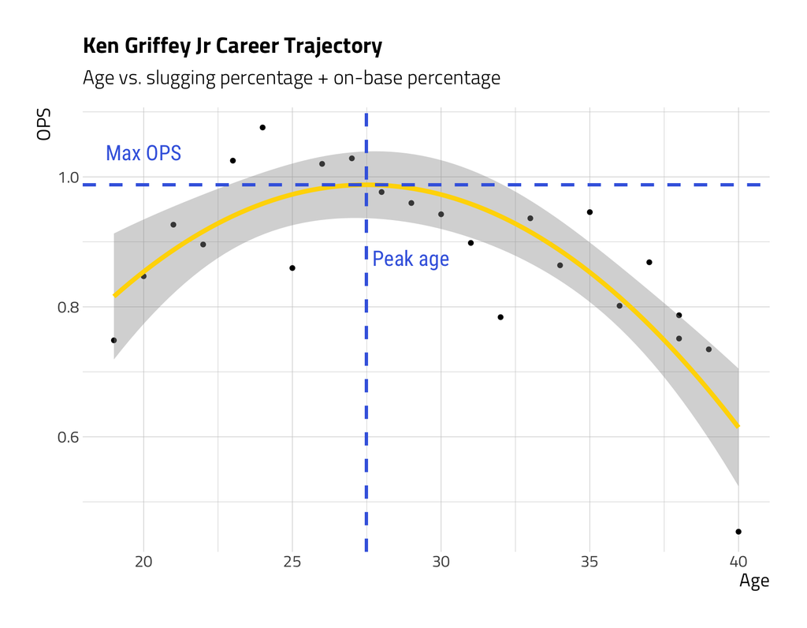

```r
# peak age labels
peak_age_label_y <- mean(KGriffeyJr$OPS)
peak_age_label_x <- kgriffeyjr_fit_model$age_max + 1.5
# max value labels
max_value_label_y <- kgriffeyjr_fit_model$max_value + 0.05
max_value_label_x <- min(KGriffeyJr$Age) + 1

# build plot
KGriffeyJr %>%
  ggplot2::ggplot(aes(x = Age, y = OPS)) +
  # add points
  ggplot2::geom_point() +
  # add smoothed line
  ggplot2::geom_smooth(method = "lm", se = TRUE, size = 1.75, color = "gold",
              # specify the formula using
              formula = y ~ poly(x = x, degree = 2, raw = TRUE)) +
  # add vertical line
  ggplot2::geom_vline(xintercept = kgriffeyjr_fit_model$age_max, linetype = "dashed",
             color = "royalblue", size = 1.25) +
  # add horizontal line
  ggplot2::geom_hline(yintercept = kgriffeyjr_fit_model$max_value, linetype = "dashed",
             color = "royalblue", size = 1.25) +
  # label for peak age
  ggplot2::annotate(geom = "text", x = c(peak_age_label_x),
                          y = c(peak_age_label_y),
           label = c("Peak age"), size = 6, color = "royalblue") +
  # label for Max OPS
  ggplot2::annotate(geom = "text", x = c(max_value_label_x),
                          y = c(max_value_label_y),
           label = c("Max OPS"), size = 6, color = "royalblue") +
  # theme
  hrbrthemes::theme_ipsum_tw(plot_title_size = 18, subtitle_size = 16,
                             axis_title_size = 15, axis_text_size = 13) +
  # graph labels
  ggplot2::labs(title = "Ken Griffey Jr Career Trajectory",
                subtitle = "Age vs. slugging percentage + on-base percentage")
```

Let’s compare this to Jose Canseco.

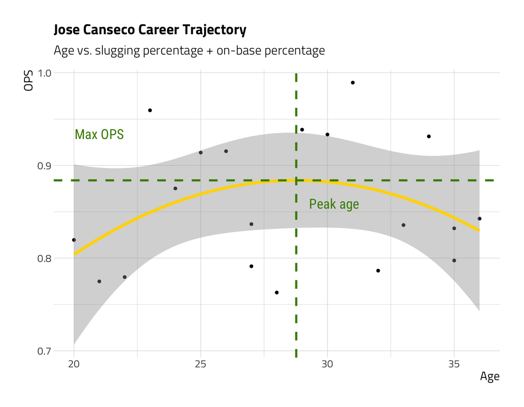

```r
jcanseco_id <- Lahman::People %>%
  filter(nameFirst == "Jose" & nameLast == "Canseco") %>%
  pull(playerID)
JCanseco <- get_stats(jcanseco_id)
jconseco_fit_model <- fit_model(JCanseco)

# peak age labels
peak_age_label_y <- mean(JCanseco$OPS)
peak_age_label_x <- jconseco_fit_model$age_max + 1.5
# max value labels
max_value_label_y <- jconseco_fit_model$max_value + 0.05
max_value_label_x <- min(JCanseco$Age) + 1

# build plot
JCanseco %>%
  ggplot2::ggplot(aes(x = Age, y = OPS)) +
  # add points
  ggplot2::geom_point() +
  # add smoothed line
  ggplot2::geom_smooth(method = "lm", se = TRUE, size = 1.75, color = "gold1",
              # specify the formula using
              formula = y ~ poly(x = x, degree = 2, raw = TRUE)) +
  # add vertical line
  ggplot2::geom_vline(xintercept = jconseco_fit_model$age_max, linetype = "dashed",
             color = "chartreuse4", size = 1.25) +
  # add horizontal line
  ggplot2::geom_hline(yintercept = jconseco_fit_model$max_value, linetype = "dashed",
             color = "chartreuse4", size = 1.25) +
  # label for peak age
  ggplot2::annotate(geom = "text", x = c(peak_age_label_x),
                          y = c(peak_age_label_y),
           label = c("Peak age"), size = 6, color = "chartreuse4") +
  # label for Max OPS
  ggplot2::annotate(geom = "text", x = c(max_value_label_x),
                          y = c(max_value_label_y),
           label = c("Max OPS"), size = 6, color = "chartreuse4") +
  # theme
  hrbrthemes::theme_ipsum_tw(plot_title_size = 18, subtitle_size = 16,
                             axis_title_size = 15, axis_text_size = 13) +
  # graph labels
  ggplot2::labs(title = "Jose Canseco Career Trajectory",
                subtitle = "Age vs. slugging percentage + on-base percentage")
```

These two graphs show very different career trajectories. Griffey’s career peaked sooner at a higher value, and had a steep decline. Canseco’s career had more of a gradual climb until it peaked at age 28.7687737 with an OPS of 0.8838838 (lower than Griffey’s).

## Calculating DEA to evaluate hitters

> To-do

## Calculating weighted slack to evaluate hitters

> To-do

## Deploy

Run this code to knit an html file and move it to `docs` folder.

```r
# create docs folder
fs::dir_create("docs")
# knit and move to docs folder
fs::file_move(path = "Index.html", new_path = "docs/Index.html")
```

Notes

Check out the baseballDBR package.